# Chicago Accessibility Analysis

Abiodun Emmanuel Ofobutu

2026-08-12

## Overview

This report analyzes accessibility to transit, schools, hospitals, and groceries across 870 Chicago neighborhoods (Census tracts), using a PostGIS spatial database built from CTA GTFS data, OpenStreetMap, and US Census data.

## Income vs. Accessibility

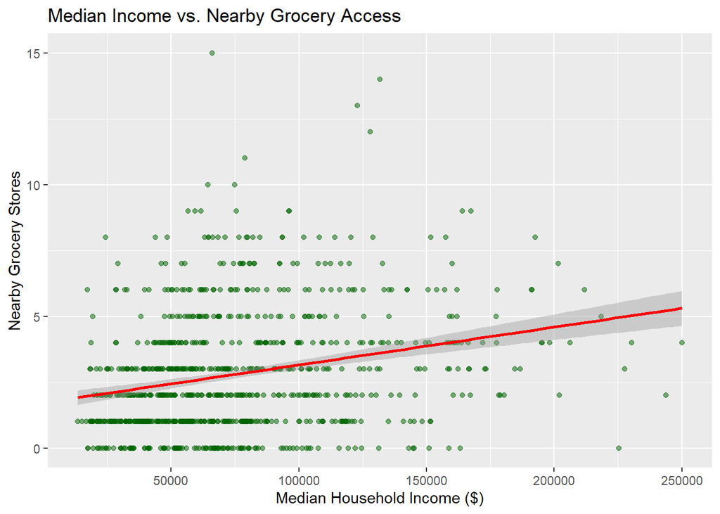

Grocery access shows a moderate positive correlation with income (r = 0.30), while transit, school, and hospital access show no meaningful income relationship (r near 0 for all three).

## Predicting Underserved Neighborhoods

A logistic regression model using population, income, density, and distance from downtown predicted whether a neighborhood falls in the bottom 25% for combined accessibility (“underserved”). All four predictors were statistically significant (p < 0.001 for three of four). Distance from downtown was the strongest driver: neighborhoods further from the city center were substantially more likely to be underserved.

At a 0.35 classification threshold, the model correctly identified 59% of genuinely underserved neighborhoods (recall), with 88 false positives out of 856 zones.

## Key Findings

1. Food/grocery access, not transit or healthcare access, shows the clearest income disparity in Chicago.
2. Distance from downtown is the single strongest predictor of poor accessibility, more than income or population alone.
3. Basic demographics only partially explain accessibility gaps, pointing to historical infrastructure and geography as major factors.